# trad_comparison

Alma Steireif

2025-05-15

# 1. libraries

```r
theme_new <- theme_classic(base_size = 12) +
  theme(axis.line = element_blank(),
        axis.text = element_text(colour = "black"),
        axis.ticks = element_line(linewidth = 0.4, colour = "black"),
        legend.key.size = unit(0.5, "cm"),
        legend.margin = margin(t = 0),
        legend.text = element_text(size = 8),
        legend.title = element_text(size = 9),
        panel.border = element_rect(linewidth = 0.4, colour = "black", fill = NA),
        panel.grid.major.y = element_line(colour = "grey90", linewidth = 0.2),
        plot.margin = margin(2, 2, 2, 2, "pt"),
        plot.title = element_text(size = 10))
theme_set(theme_new)
```

# 2. data

```r
#load("C:/Users/Almas/Desktop/UNI_LEIPSI/Thesis/Thesis_Rproject/data/20250120_netdata.RData")
net_data <- read.csv("C:/Users/Almas/Desktop/UNI_LEIPSI/Thesis/Thesis_Rproject/data/net_data_long.csv")
load("C:/Users/Almas/Desktop/UNI_LEIPSI/Thesis/Thesis_Rproject/data/20250203_full_bowltrap.RData")
```

# 3. data preparation

```r
th <- 0.5

flower_cam <- read.csv("C:/Users/Almas/Desktop/UNI_LEIPSI/Thesis/Thesis_Rproject/data/bioclip_flower_cams.csv")%>%
  #filter out Classification_Category == "other_families"
  filter(Classification_Category != "other_families") %>%
  dplyr::select(-Image_Path, -Classification_Category , -Order)%>%
  #remove all rows that have a family confidence below set threshold th
  filter(Family_Confidence >= th)%>%
    mutate(Site_Type = ifelse(site %in% c("WED", "KOT", "WDG", "BUH"), "Young Restored", "Reference"))
```

```r
bowltrap <- bowltrap_clean %>%
  #select all columns except "small_"
  dplyr::select(Site:acalyptrate, -Color, -Site_type) %>%
  #pivot into long format
  pivot_longer(cols =  apidae:acalyptrate,
               names_to = "Family",
               values_to = "Count") %>%

  #remove all rows that have a 0 "count" value
  filter(Count != 0) %>%

  #remove rows that have null values in the "Family" column
  filter(!is.na(Family)) %>%

   # change every family name to first letter uppercase to have uniformity
  mutate(Family = str_to_title(Family)) %>%

  #add column "Method" with value "Bowltrap"
  mutate(Method = "Bowltrap")

netting <- net_data %>%
  #select the six columns in common with the bowltrap data
  dplyr::select(Site=site, Transect=transect, Date = date, Family=family, Count=total_interaction) %>%

  # change every family name to first letter uppercase to have uniformity
  mutate(Family = str_to_title(Family)) %>%

  #remove rows that have null values in the "Family" column
  filter(!is.na(Family)) %>%

  #combine rows with the same site, transect, date and family and sum up the "Count" values
  group_by(Site, Transect, Date, Family) %>%
  summarise(Count = sum(Count)) %>%

  #add column "Method" with value "Netting"
  mutate(Method = "Netting")
#combine the two datasets
trad_meth<- rbind(bowltrap, netting)
rm(bowltrap_clean, net_data)
```

# 4. Combined traditional methods - trad_meth

## 4.1. NMDS analysis for family composition between the sites

```r
# Create a community matrix
community_matrix_trad_meth <- trad_meth%>%
  group_by(Site, Family) %>%
  summarise(Count = sum(Count), .groups = "drop") %>%
  pivot_wider(names_from = Family, values_from = Count, values_fill = 0) %>%
  column_to_rownames(var = "Site") # Convert 'Site' column to row names

# Perform NMDS using Bray-Curtis distance
set.seed(123)
nmds_result_trad_meth <- metaMDS(community_matrix_trad_meth, distance = "bray", k = 2, trymax = 100)
```

```
## Square root transformation
## Wisconsin double standardization
## *** Best solution repeated 4 times
```

```r
# View results
print(nmds_result_trad_meth)
```

```
##
## Call:
## metaMDS(comm = community_matrix_trad_meth, distance = "bray",      k = 2, trymax = 100)
##
## global Multidimensional Scaling using monoMDS
##
## Data:     wisconsin(sqrt(community_matrix_trad_meth))
## Distance: bray
##
## Dimensions: 2
## Stress:     0.1474419
## Stress type 1, weak ties
## Best solution was repeated 4 times in 20 tries
## The best solution was from try 1 (random start)
## Scaling: centring, PC rotation, halfchange scaling
## Species: expanded scores based on 'wisconsin(sqrt(community_matrix_trad_meth))'
```

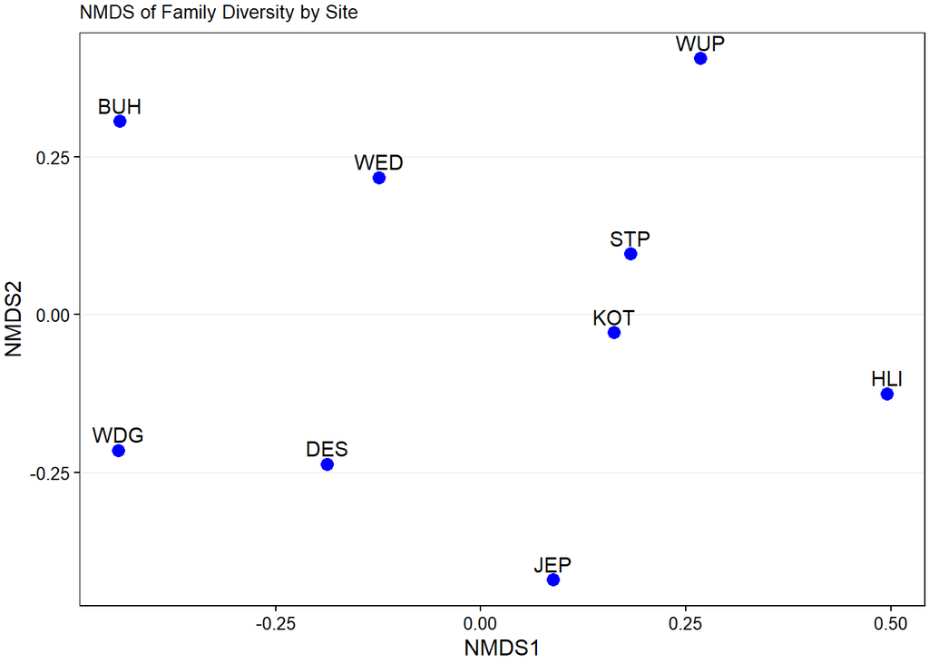

```r
# Extract site scores for plotting
site_scores_trad_meth <- as.data.frame(scores(nmds_result_trad_meth, display = "sites"))
site_scores_trad_meth$Site <- rownames(site_scores_trad_meth)

# Create a scatterplot
ggplot(site_scores_trad_meth, aes(x = NMDS1, y = NMDS2, label = Site)) +
  geom_point(size = 3, color = "blue") +
  geom_text(vjust = -0.5, size = 4) +
  #  theme_minimal() +
  labs(title = "NMDS of Family Diversity by Site",
       x = "NMDS1",
       y = "NMDS2")
```

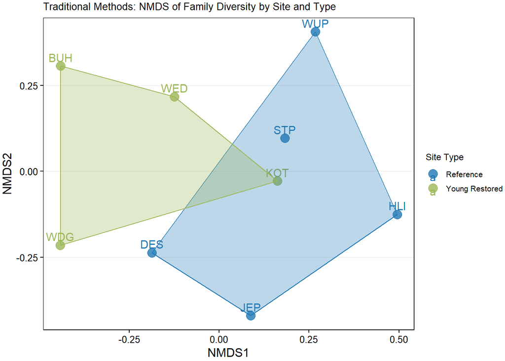

```r
# Create a vector indicating site type (restored vs. reference)
site_scores_trad_meth <- site_scores_trad_meth %>%
  mutate(Site_Type = ifelse(Site %in% c("WED", "KOT", "WDG", "BUH"), "Young Restored", "Reference"))

# Custom color palette
#custom_colors <- c("Young Restored" = "steelblue", "Reference" = "darkorange")
custom_colors <- c("Young Restored" = "#9BB655FF", "Reference" = "#1F78B4")

# Plot with customized colors
ggplot(site_scores_trad_meth, aes(x = NMDS1, y = NMDS2, color = Site_Type, label = Site)) +
  geom_point(size = 4, alpha = 0.8) + # Adjust alpha for transparency if needed
  geom_text(vjust = -0.5, size = 4) +
  scale_color_manual(values = custom_colors) + # Apply custom colors
  geom_polygon(data = site_scores_trad_meth %>%
                 group_by(Site_Type) %>%
                 slice(chull(NMDS1, NMDS2)),
               aes(group = Site_Type, fill = Site_Type),
               alpha = 0.3,show.legend = FALSE) + # Add convex hull
  scale_fill_manual(values = custom_colors) + # Apply fill colors to polygons
  #  theme_minimal() +
  labs(title = "Traditional Methods: NMDS of Family Diversity by Site and Type",
       x = "NMDS1",
       y = "NMDS2",
       color = "Site Type") # Update legend title
```

## 4.2. NMDS - Splitting traditional methods

```r
# Create a community matrix with Site and Transect combined
community_matrix_trad_meth_split <- trad_meth%>%
  mutate(Site_Meth = paste(Site, Method, sep = "_")) %>% # Combine Site and Method
  group_by(Site_Meth, Family) %>%
  summarise(Count = sum(Count), .groups = "drop") %>%
  pivot_wider(names_from = Family, values_from = Count, values_fill = 0) %>%
  column_to_rownames(var = "Site_Meth") # Use combined Site_Transect as row names


# Perform NMDS using Bray-Curtis distance
set.seed(123)
nmds_result_trad_meth_split <- metaMDS(community_matrix_trad_meth_split, distance = "bray", k = 2, trymax = 100)
```

```
## Square root transformation
## Wisconsin double standardization
## *** Best solution was not repeated -- monoMDS stopping criteria:
##     27: no. of iterations >= maxit
##     73: stress ratio > sratmax
```

```r
# View results
print(nmds_result_trad_meth_split)
```

```
##
## Call:
## metaMDS(comm = community_matrix_trad_meth_split, distance = "bray",      k = 2, trymax = 100)
##
## global Multidimensional Scaling using monoMDS
##
## Data:     wisconsin(sqrt(community_matrix_trad_meth_split))
## Distance: bray
##
## Dimensions: 2
## Stress:     0.08945519
## Stress type 1, weak ties
## Best solution was not repeated after 100 tries
## The best solution was from try 36 (random start)
## Scaling: centring, PC rotation, halfchange scaling
## Species: expanded scores based on 'wisconsin(sqrt(community_matrix_trad_meth_split))'
```

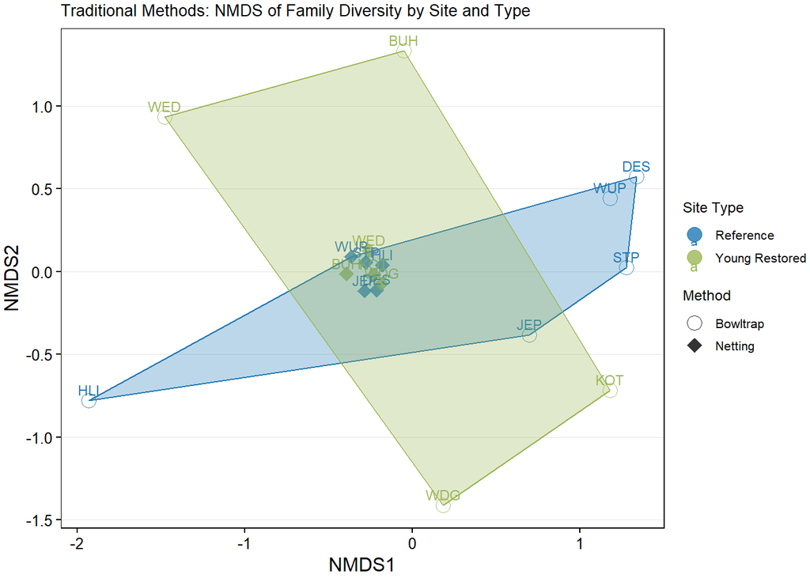

```r
# Extract site scores for plotting
site_scores_trad_meth_split <- as.data.frame(scores(nmds_result_trad_meth_split, display = "sites"))
site_scores_trad_meth_split$Site <- rownames(site_scores_trad_meth_split)

# Create a vector indicating site type (restored vs. reference)
site_scores_trad_meth_split <- site_scores_trad_meth_split %>%
  #if the site names begins with "WED_", "KOT_", "WDG_", "BUH_" then it is a "Young Restored" site, otherwise it is a "Reference" site
  mutate(Site_Type = ifelse(str_detect(Site, "WED_|KOT_|WDG_|BUH_"), "Young Restored", "Reference")) %>%
  #if the site names ends with "_Bowltrap" then it is a "Bowltrap" site, otherwise it is a "Netting" site
  mutate(Method = ifelse(str_detect(Site, "_Bowltrap"), "Bowltrap", "Netting"))%>%
  #only keep first 3 letters of the site name
  mutate(Site = str_sub(Site, 1, 3))

# Custom color palette
#custom_colors <- c("Young Restored" = "steelblue", "Reference" = "darkorange")
custom_colors <- c("Young Restored" = "#9BB655FF", "Reference" = "#1F78B4")
custom_shapes <- c("Bowltrap" = 1, "Netting" = 18) # 16 = solid circle, 17 = triangle

# Plot with customized colors and shapes for Method
ggplot(site_scores_trad_meth_split, aes(x = NMDS1, y = NMDS2, color = Site_Type, label = Site, shape = Method)) +
  geom_point(size = 4, alpha = 0.8) + # Adjust alpha for transparency if needed
  geom_text(vjust = -0.5, size = 3) +  # Adjust text position
  scale_color_manual(values = custom_colors) + # Apply custom colors
  scale_shape_manual(values = custom_shapes) + # Apply custom shapes
  geom_polygon(data = site_scores_trad_meth_split %>%
                 group_by(Site_Type) %>%
                 slice(chull(NMDS1, NMDS2)),
               aes(group = Site_Type, fill = Site_Type),
               alpha = 0.3,show.legend = FALSE) + # Add convex hull
  scale_fill_manual(values = custom_colors) + # Apply fill colors to polygons
  #geom_polygon(data = site_scores2 %>%
  #               group_by(Site) %>%
  #               slice(chull(NMDS1, NMDS2)),
  #             aes(group = Site, fill = Site),
  #             alpha = 0.3,show.legend = FALSE,color = "white") + # Add convex hull

  #  theme_minimal() +
  labs(title = "Traditional Methods: NMDS of Family Diversity by Site and Type",
       x = "NMDS1",
       y = "NMDS2",
       color = "Site Type",
       shape = "Method") # Update legend title
```

## 4.3. again, but removing outliers in pan traps

- in two bowls in Dessau, there were >10 individuals of a single family (Mordellidae), which is very likely skewing the results.
- let’s see what happens if we remove these two bowls

```r
# Remove the two bowls with >10 individuals of Mordellidae using the bowltrap method
#if count is less than 10, keep the row, otherwise remove it
trad_meth_clean <- trad_meth%>%
  filter(!(Site == "DES" & Method == "Bowltrap" & Family == "Mordellidae" & Count > 10))

# Create a community matrix with Site and Transect combined
community_matrix_trad_meth_clean <- trad_meth_clean %>%
  group_by(Site, Family) %>%
  summarise(Count = sum(Count), .groups = "drop") %>%
  pivot_wider(names_from = Family, values_from = Count, values_fill = 0) %>%
  column_to_rownames(var = "Site") # Convert 'Site' column to row names


# Perform NMDS using Bray-Curtis distance
set.seed(123)
nmds_result_trad_meth_clean <- metaMDS(community_matrix_trad_meth_clean, distance = "bray", k = 2, trymax = 100)
```

```
## Square root transformation
## Wisconsin double standardization
## *** Best solution repeated 4 times
```

```r
# View results
print(nmds_result_trad_meth_clean)
```

```
##
## Call:
## metaMDS(comm = community_matrix_trad_meth_clean, distance = "bray",      k = 2, trymax = 100)
##
## global Multidimensional Scaling using monoMDS
##
## Data:     wisconsin(sqrt(community_matrix_trad_meth_clean))
## Distance: bray
##
## Dimensions: 2
## Stress:     0.1427291
## Stress type 1, weak ties
## Best solution was repeated 4 times in 20 tries
## The best solution was from try 0 (metric scaling or null solution)
## Scaling: centring, PC rotation, halfchange scaling
## Species: expanded scores based on 'wisconsin(sqrt(community_matrix_trad_meth_clean))'
```

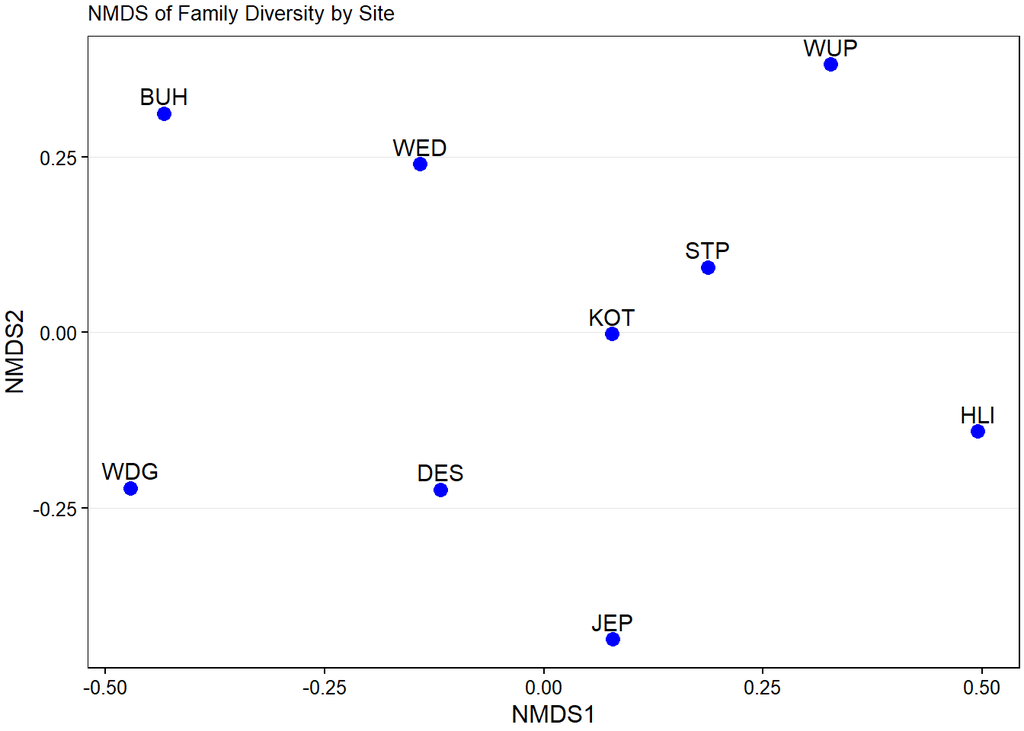

```r
# Extract site scores for plotting
site_scores_trad_meth_clean <- as.data.frame(scores(nmds_result_trad_meth_clean, display = "sites"))
site_scores_trad_meth_clean$Site <- rownames(site_scores_trad_meth_clean)

# Create a scatterplot
ggplot(site_scores_trad_meth_clean, aes(x = NMDS1, y = NMDS2, label = Site)) +
  geom_point(size = 3, color = "blue") +
  geom_text(vjust = -0.5, size = 4) +
  #  theme_minimal() +
  labs(title = "NMDS of Family Diversity by Site",
       x = "NMDS1",
       y = "NMDS2")
```

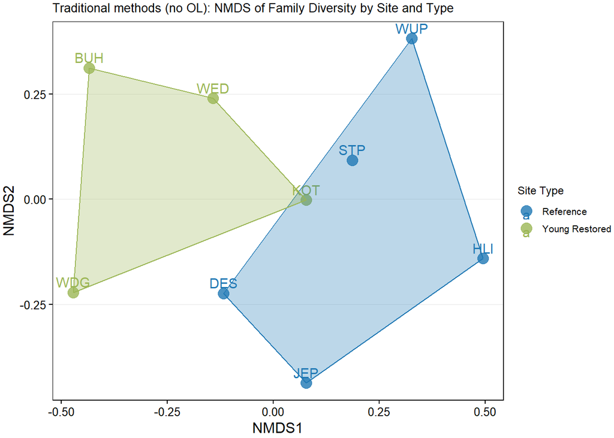

```r
# Create a vector indicating site type (restored vs. reference)
site_scores_trad_meth_clean <- site_scores_trad_meth_clean %>%
  mutate(Site_Type = ifelse(Site %in% c("WED", "KOT", "WDG", "BUH"), "Young Restored", "Reference"))

# Custom color palette
#custom_colors <- c("Young Restored" = "steelblue", "Reference" = "darkorange")
custom_colors <- c("Young Restored" = "#9BB655FF", "Reference" = "#1F78B4")

# Plot with customized colors
ggplot(site_scores_trad_meth_clean, aes(x = NMDS1, y = NMDS2, color = Site_Type, label = Site)) +
  geom_point(size = 4, alpha = 0.8) + # Adjust alpha for transparency if needed
  geom_text(vjust = -0.5, size = 4) +
  scale_color_manual(values = custom_colors) + # Apply custom colors
  geom_polygon(data = site_scores_trad_meth_clean %>%
                 group_by(Site_Type) %>%
                 slice(chull(NMDS1, NMDS2)),
               aes(group = Site_Type, fill = Site_Type),
               alpha = 0.3,show.legend = FALSE) + # Add convex hull
  scale_fill_manual(values = custom_colors) + # Apply fill colors to polygons
  #  theme_minimal() +
  labs(title = "Traditional methods (no OL): NMDS of Family Diversity by Site and Type",
       x = "NMDS1",
       y = "NMDS2",
       color = "Site Type") # Update legend title
```

# 5. NETTING

## 5.1. Netting - NMDS

```r
# Step 1: Create the community matrix
community_matrix_net <- trad_meth%>%
  filter(Method == "Netting") %>% # Filter for Netting method only
  group_by(Site, Family) %>%
  summarise(Count = n(), .groups = "drop") %>%
  pivot_wider(names_from = Family, values_from = Count, values_fill = list(Count = 0)) %>%
  column_to_rownames(var = "Site") # Convert 'site' column to row names

# Step 2: Perform NMDS using Bray-Curtis distance
set.seed(123)
nmds_result_net <- metaMDS(community_matrix_net, distance = "bray", k = 2, trymax = 100)
```

```
## *** Best solution repeated 3 times
```

```r
# View results
print(nmds_result_net)
```

```
##
## Call:
## metaMDS(comm = community_matrix_net, distance = "bray", k = 2,      trymax = 100)
##
## global Multidimensional Scaling using monoMDS
##
## Data:     community_matrix_net
## Distance: bray
##
## Dimensions: 2
## Stress:     0.1144708
## Stress type 1, weak ties
## Best solution was repeated 3 times in 20 tries
## The best solution was from try 9 (random start)
## Scaling: centring, PC rotation, halfchange scaling
## Species: expanded scores based on 'community_matrix_net'
```

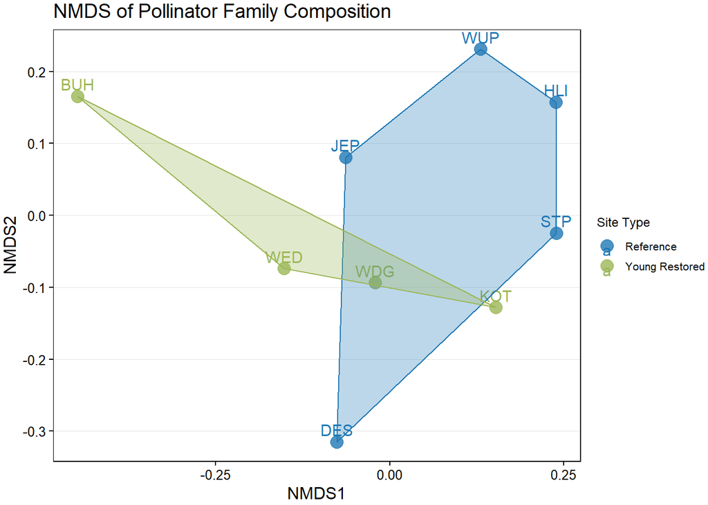

```r
# Step 3: Extract site scores for plotting
site_scores_net <- as.data.frame(scores(nmds_result_net, display = "sites"))
site_scores_net$Site <- rownames(site_scores_net)

# Step 4: Add Site_Type (Young Restored vs. Reference) to the site scores
site_scores_net <- site_scores_net %>%
  mutate(Site_Type = ifelse(Site %in% c("WED", "KOT", "WDG", "BUH"), "Young Restored", "Reference"))

# Custom color palette
#custom_colors <- c("Young Restored" = "steelblue", "Reference" = "darkorange")
custom_colors <- c("Young Restored" = "#9BB655FF", "Reference" = "#1F78B4")

# Step 5: Plot with customized colors
(nmds_netting <- ggplot(site_scores_net, aes(x = NMDS1, y = NMDS2, color = Site_Type, label = Site)) +
  geom_point(size = 4, alpha = 0.8) + # Adjust alpha for transparency if needed
  geom_text(vjust = -0.5, size = 4) +
  scale_color_manual(values = custom_colors) + # Apply custom colors
  geom_polygon(data = site_scores_net %>%
                 group_by(Site_Type) %>%
                 slice(chull(NMDS1, NMDS2)),
               aes(group = Site_Type, fill = Site_Type),
               alpha = 0.3, show.legend = FALSE) + # Add convex hull
  scale_fill_manual(values = custom_colors) + # Apply fill colors to polygons
  labs(title = "NMDS of Pollinator Family Composition",
       x = "NMDS1",
       y = "NMDS2",
       color = "Site Type")+
    #make title font 14
  theme(plot.title = element_text(size = 14))) # Update legend title
```

Stress: tells us how well the NMDS represents the data in the reduced dimensions (2D in this case). A stress value of 0.2 or lower is considered good, while a value above 0.3 indicates a poor representation. - In this case: Stress < 0.12, so a 2D solution is adequate.

## 5.2. Netting - PERMANOVA & ANOSIM

```r
#netting community matrix
community_matrix_net <- trad_meth %>%
  filter(Method == "Netting") %>% # Filter for Netting method only
  group_by(Site, Family) %>%
  summarise(Count = n(), .groups = "drop") %>%
  pivot_wider(names_from = Family, values_from = Count, values_fill = list(Count = 0)) %>%
  column_to_rownames(var = "Site") # Convert 'site' column to row names

#Compute the Bray-Curtis distance
bc_distance_net <- vegdist(community_matrix_net, method = "bray")

# Create a metadata table
site_metadata_net <- data.frame(
  Site = rownames(community_matrix_net),
  Site_Type = ifelse(rownames(community_matrix_net) %in% c("WED", "KOT", "WDG", "BUH"),
                     "Young restored", "Reference")
)

#make sure rownames match the order in bc_distance:
site_metadata_net <- site_metadata_net[match(rownames(community_matrix_net), site_metadata_net$Site), ]

#Run PERMANOVA using adonis2()
permanova_net <- adonis2(bc_distance_net ~ Site_Type, data = site_metadata_net, permutations = 999)
print(permanova_net)
```

```
## Permutation test for adonis under reduced model
## Terms added sequentially (first to last)
## Permutation: free
## Number of permutations: 999
##
## adonis2(formula = bc_distance_net ~ Site_Type, data = site_metadata_net, permutations = 999)
##           Df SumOfSqs      R2      F Pr(>F)
## Site_Type  1  0.11967 0.15143 1.2491  0.181
## Residual   7  0.67063 0.84857
## Total      8  0.79030 1.00000
```

```r
#ANOSIM for additional insight
anosim_result_net <- anosim(bc_distance_net, grouping = site_metadata_net$Site_Type, permutations = 999)
summary(anosim_result_net)
```

```
##
## Call:
## anosim(x = bc_distance_net, grouping = site_metadata_net$Site_Type,      permutations = 999)
## Dissimilarity: bray
##
## ANOSIM statistic R: 0.1875
##       Significance: 0.132
##
## Permutation: free
## Number of permutations: 999
##
## Upper quantiles of permutations (null model):
##   90%   95% 97.5%   99%
## 0.228 0.322 0.422 0.459
##
## Dissimilarity ranks between and within classes:
##                0%    25%   50%    75% 100%  N
## Between         3 14.125 19.50 27.875   36 20
## Reference       1  8.250 12.75 24.250   35 10
## Young restored  5  7.750 18.00 27.125   33  6
```

## 5.3. Netting - Hill numbers

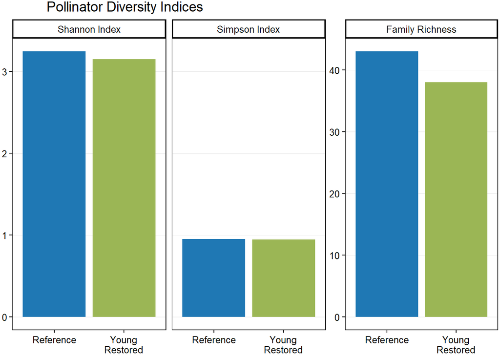

```r
#calculate species richness, shannon and simpson index for netting data with vegan package
# Calculate Hill numbers (species richness, Shannon, and Simpson index)
hill_numbers_net <- netting%>%
  #add Site_type column
  mutate(Site_Type = ifelse(Site %in% c("WED", "KOT", "WDG", "BUH"), "Young Restored", "Reference")) %>%
  group_by(Site_Type, Family) %>%
  summarise(Count = n(), .groups = "drop") %>%
  pivot_wider(names_from = Family, values_from = Count, values_fill = list(Count = 0)) %>%
  column_to_rownames(var = "Site_Type") %>%
  # Calculate Hill numbers
  mutate(Species_Richness = specnumber(.),
         Shannon_Index = diversity(., index = "shannon"),
         Simpson_Index = diversity(., index = "simpson"))%>%
  #remove all columns that are not "Species_Richness", "Shannon_Index" or "Simpson_Index"
  dplyr::select(Species_Richness, Shannon_Index, Simpson_Index) %>%
  #add column "Site_Type" with value "Young Restored" or "Reference"
  mutate(Site_Type = rownames(.))

# Hill numbers long format
hill_numbers_long_net <- hill_numbers_net %>%
  pivot_longer(cols = c(Species_Richness, Shannon_Index, Simpson_Index),
               names_to = "Index",
               values_to = "Value")
#index labels
facet_labels_net <- c("Species_Richness" = "Family Richness",
                  "Shannon_Index" = "Shannon Index",
                  "Simpson_Index" = "Simpson Index")
# Barplot of Shannon and Simpson indices (filtered out species richness)
shan_simp_net <- hill_numbers_long_net %>%
  filter(Index != "Species_Richness") %>%
  ggplot(aes(x = Site_Type, y = Value, fill = Site_Type)) +
  geom_bar(stat = "identity", position = "dodge") +
  #  theme_minimal() +
  facet_wrap(~ Index, labeller = labeller(Index = facet_labels_net)) +  # Apply custom facet labels
  scale_fill_manual(values = custom_colors) +   # Apply custom colors
  theme(
    legend.position = "none",
    axis.title.x = element_blank(),   # Remove x-axis title
    axis.title.y = element_blank(),   # Remove y-axis title
  ) +
  scale_x_discrete(labels = function(x) gsub("Young Restored", "Young\nRestored", x))  # Split label into two lines

# Barplot of Species Richness
rich_net <- hill_numbers_long_net %>%
  filter(Index == "Species_Richness") %>%
  ggplot(aes(x = Site_Type, y = Value, fill = Site_Type)) +
  geom_bar(stat = "identity", position = "dodge") +
  #  theme_minimal() +
  facet_wrap(~ Index, labeller = labeller(Index = facet_labels_net)) +  # Apply custom facet labels
  scale_fill_manual(values = custom_colors, name = "Site Type") +   # Apply custom colors
  theme(
    legend.position = "none",
    axis.title.x = element_blank(),   # Remove x-axis title
    axis.title.y = element_blank(),   # Remove y-axis title
    scale_y_continuous(position = "left"),# Put y-axis on the left side instead of right
    legend.title = element_text(size = 10),  # Adjust legend title font size
    legend.text = element_text(size = 8)    # Adjust legend text font size
  ) +
  scale_x_discrete(labels = function(x) gsub("Young Restored", "Young\nRestored", x))  # Split label into two lines

# Combine the two plots into one layout

title <- textGrob(
  "Pollinator Diversity Indices",
  gp = gpar(fontsize = 14),
  vjust = 1,
  x = unit(0.25, "npc"),  # Slight shift to the right
  y = unit(0.95, "npc")   # Position title vertically
)

# Combine the plots with the left-aligned title
combined_plot_net <- grid.arrange(
  shan_simp_net,
  rich_net,
  ncol = 2,
  top = title,
  widths = c(1.33, 0.7)
)
```

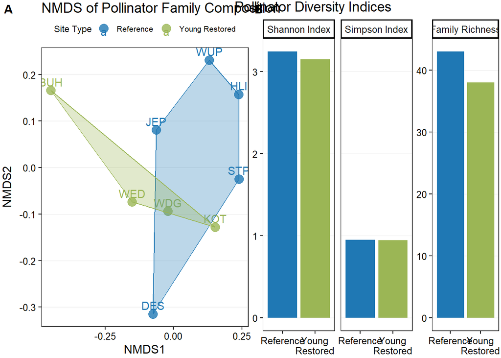

```r
#combine nmds_netting and hill numbers plots
library(cowplot)
(combi2<- cowplot::plot_grid(
  nmds_netting+theme(legend.position = "top"),
  combined_plot_net,
  ncol =2,
  labels = c("A", "B"),
  label_size = 12
  #proportional height
  #rel_widths = c(0.8, 1.1)
))
```

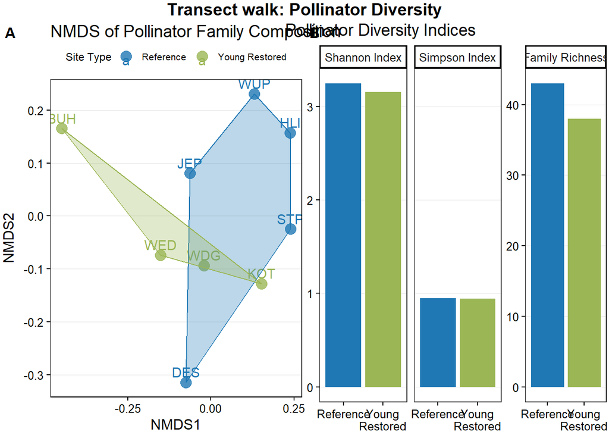

```r
(combi_final <- ggdraw() +
  draw_label("Transect walk: Pollinator Diversity", fontface = 'bold', x = 0.5, y = 0.98, hjust = 0.5, size = 14) +
  draw_plot(combi2, y = 0, height = 0.95))
```

```r
#save the combined plot

ggsave("C:/Users/Almas/Desktop/UNI_LEIPSI/Thesis/Thesis_Rproject/figures/combi_netting2.png",
       plot = combi_final,
       width = 12, height = 6, dpi = 600)
```

## 5.4. Netting - Site type counts

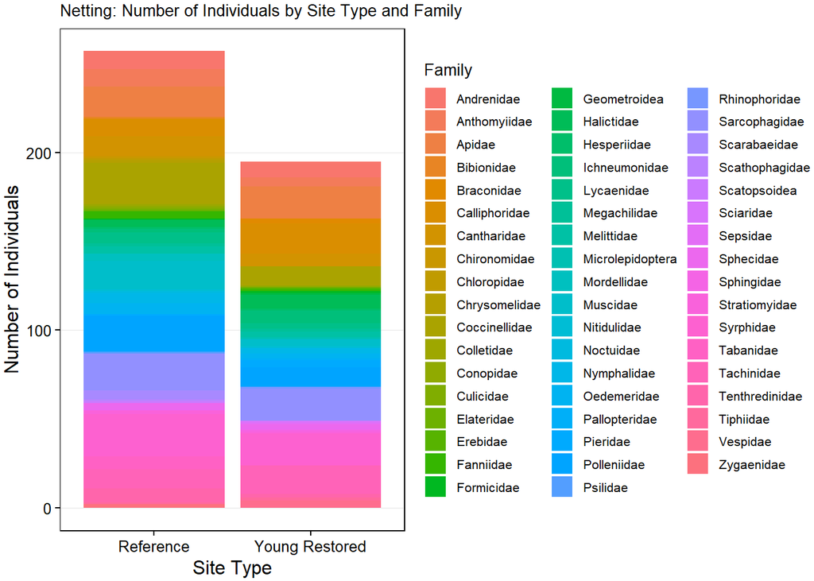

```r
# bar plot of count the number of individuals per site type, color by family
netting %>%
  #add Site_type column
  mutate(Site_Type = ifelse(Site %in% c("WED", "KOT", "WDG", "BUH"), "Young Restored", "Reference")) %>%
  group_by(Site_Type, Family) %>%
  summarise(Count = n(), .groups = "drop") %>%
  ggplot(aes(x = Site_Type, y = Count, fill = Family)) +
  geom_bar(stat = "identity", position = "stack") +
  #  theme_minimal() +
  labs(title = "Netting: Number of Individuals by Site Type and Family",
       x = "Site Type",
       y = "Number of Individuals") +
  #scale_fill_manual(values = custom_colors) +   # Apply custom colors
  theme(
    legend.position = "right",
    #axis.title.x = element_blank(),   # Remove x-axis title
    #axis.title.y = element_blank(),   # Remove y-axis title
    scale_y_continuous(position = "left"),# Put y-axis on the left side instead of right
    legend.title = element_text(size = 10),  # Adjust legend title font size
    legend.text = element_text(size = 8)    # Adjust legend text font size
  )
```

# 6. PAN TRAPS

## 6.1. Bowltrap - NMDS

```r
# Step 1: Create the community matrix
community_matrix_bowltrap <- trad_meth%>%
  filter(Method == "Bowltrap") %>% # Filter for Bowltrap method only
  group_by(Site, Family) %>%
  summarise(Count = n(), .groups = "drop") %>%
  pivot_wider(names_from = Family, values_from = Count, values_fill = list(Count = 0)) %>%
  column_to_rownames(var = "Site") # Convert 'site' column to row names

# Step 2: Perform NMDS using Bray-Curtis distance
set.seed(123)
nmds_result_bowltrap <- metaMDS(community_matrix_bowltrap, distance = "bray", k = 2, trymax = 100)
```

```
## *** Best solution was not repeated -- monoMDS stopping criteria:
##     53: no. of iterations >= maxit
##     47: stress < smin
```

```r
# View results
print(nmds_result_bowltrap)
```

```
##
## Call:
## metaMDS(comm = community_matrix_bowltrap, distance = "bray",      k = 2, trymax = 100)
##
## global Multidimensional Scaling using monoMDS
##
## Data:     community_matrix_bowltrap
## Distance: bray
##
## Dimensions: 2
## Stress:     6.683152e-05
## Stress type 1, weak ties
## Best solution was not repeated after 100 tries
## The best solution was from try 31 (random start)
## Scaling: centring, PC rotation
## Species: expanded scores based on 'community_matrix_bowltrap'
```

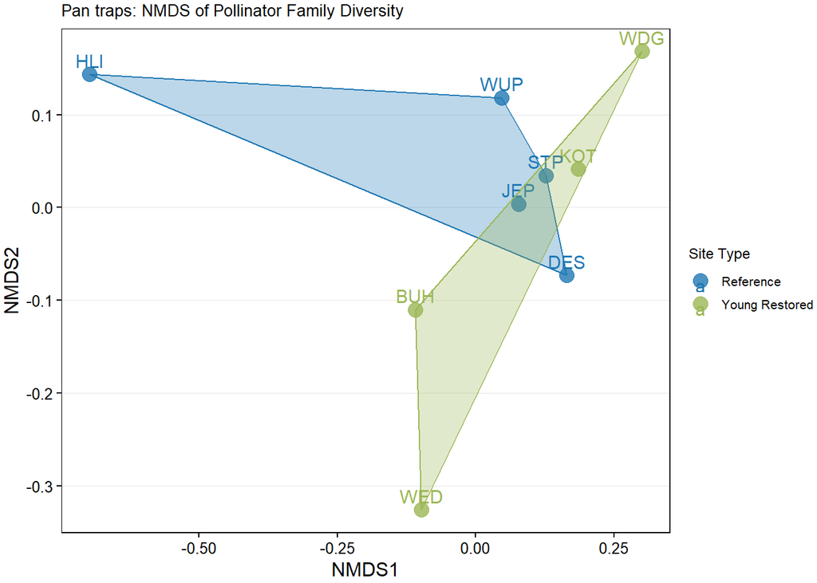

```r
# Step 3: Extract site scores for plotting
site_scores_bowltrap <- as.data.frame(scores(nmds_result_bowltrap, display = "sites"))
site_scores_bowltrap$Site <- rownames(site_scores_bowltrap)

# Step 4: Add Site_Type (Young Restored vs. Reference) to the site scores
site_scores_bowltrap <- site_scores_bowltrap %>%
  mutate(Site_Type = ifelse(Site %in% c("WED", "KOT", "WDG", "BUH"), "Young Restored", "Reference"))

# Custom color palette
#custom_colors <- c("Young Restored" = "steelblue", "Reference" = "darkorange")
custom_colors <- c("Young Restored" = "#9BB655FF", "Reference" = "#1F78B4")
# Step 5: Plot with customized colors
ggplot(site_scores_bowltrap, aes(x = NMDS1, y = NMDS2, color = Site_Type, label = Site)) +
  geom_point(size = 4, alpha = 0.8) + # Adjust alpha for transparency if needed
  geom_text(vjust = -0.5, size = 4) +
  scale_color_manual(values = custom_colors) + # Apply custom colors
  geom_polygon(data = site_scores_bowltrap %>%
                 group_by(Site_Type) %>%
                 slice(chull(NMDS1, NMDS2)),
               aes(group = Site_Type, fill = Site_Type),
               alpha = 0.3, show.legend = FALSE) + # Add convex hull
  scale_fill_manual(values = custom_colors) + # Apply fill colors to polygons
  #  theme_minimal() +
  labs(title = "Pan traps: NMDS of Pollinator Family Diversity",
       x = "NMDS1",
       y = "NMDS2",
       color = "Site Type") # Update legend title
```

For the pan traps, we have too little data to get a good NMDS solution. Even though the stress value is close to zero, there is a warning that “Warning: stress is (nearly) zero: you may have insufficient data”.

## 6.2. Bowltrap - PERMANOVA & ANOSIM

```r
#bowltrap community matrix
community_matrix_bowl <- trad_meth %>%
  filter(Method == "Bowltrap") %>% # Filter for Bowltrap method only
  group_by(Site, Family) %>%
  summarise(Count = n(), .groups = "drop") %>%
  pivot_wider(names_from = Family, values_from = Count, values_fill = list(Count = 0)) %>%
  column_to_rownames(var = "Site") # Convert 'site' column to row names

#Compute the Bray-Curtis distance
bc_distance_bowl <- vegdist(community_matrix_bowl, method = "bray")

# Create a metadata table
site_metadata_bowl <- data.frame(
  Site = rownames(community_matrix_bowl),
  Site_Type = ifelse(rownames(community_matrix_bowl) %in% c("WED", "KOT", "WDG", "BUH"),
                     "Young restored", "Reference")
)

#Make sure rownames match the order in bc_distance:
site_metadata_bowl <- site_metadata_bowl[match(rownames(community_matrix_bowl), site_metadata_bowl$Site), ]

#Run PERMANOVA using adonis2()
permanova_bowl <- adonis2(bc_distance_bowl ~ Site_Type, data = site_metadata_bowl, permutations = 999)
print(permanova_bowl)
```

```
## Permutation test for adonis under reduced model
## Terms added sequentially (first to last)
## Permutation: free
## Number of permutations: 999
##
## adonis2(formula = bc_distance_bowl ~ Site_Type, data = site_metadata_bowl, permutations = 999)
##           Df SumOfSqs      R2      F Pr(>F)
## Site_Type  1  0.48463 0.15391 1.2733  0.179
## Residual   7  2.66424 0.84609
## Total      8  3.14887 1.00000
```

```r
#ANOSIM for additional insight
anosim_result_bowl <- anosim(bc_distance_bowl, grouping = site_metadata_bowl$Site_Type, permutations = 999)
summary(anosim_result_bowl)
```

```
##
## Call:
## anosim(x = bc_distance_bowl, grouping = site_metadata_bowl$Site_Type,      permutations = 999)
## Dissimilarity: bray
##
## ANOSIM statistic R: 0.1344
##       Significance: 0.149
##
## Permutation: free
## Number of permutations: 999
##
## Upper quantiles of permutations (null model):
##   90%   95% 97.5%   99%
## 0.184 0.259 0.419 0.569
##
## Dissimilarity ranks between and within classes:
##                0%    25% 50% 75% 100%  N
## Between         1 12.750  27  27   27 20
## Reference       2  5.125  11  27   27 10
## Young restored 10 14.250  27  27   27  6
```

# 7. Flower camera

## 7.1. Flower camera - NMDS

```r
# Step 1: Create the community matrix
community_matrix_cam <- flower_cam %>%
  group_by(site, Family) %>%
  summarise(Count = n(), .groups = "drop") %>%
  pivot_wider(names_from = Family, values_from = Count, values_fill = list(Count = 0)) %>%
  column_to_rownames(var = "site") # Convert 'site' column to row names

# Step 2: Perform NMDS using Bray-Curtis distance
set.seed(123)
nmds_result_cam <- metaMDS(community_matrix_cam, distance = "bray", k = 2, trymax = 100)
```

```
## Square root transformation
## Wisconsin double standardization
## *** Best solution repeated 4 times
```

```r
# View results
print(nmds_result_cam)
```

```
##
## Call:
## metaMDS(comm = community_matrix_cam, distance = "bray", k = 2,      trymax = 100)
##
## global Multidimensional Scaling using monoMDS
##
## Data:     wisconsin(sqrt(community_matrix_cam))
## Distance: bray
##
## Dimensions: 2
## Stress:     0.09449401
## Stress type 1, weak ties
## Best solution was repeated 4 times in 20 tries
## The best solution was from try 0 (metric scaling or null solution)
## Scaling: centring, PC rotation, halfchange scaling
## Species: expanded scores based on 'wisconsin(sqrt(community_matrix_cam))'
```

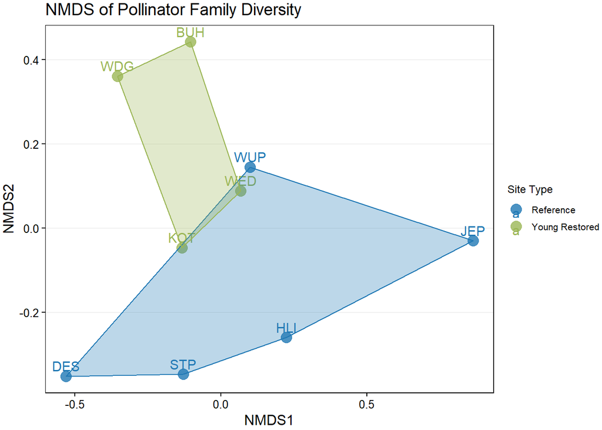

```r
# Step 3: Extract site scores for plotting
site_scores_cam <- as.data.frame(scores(nmds_result_cam, display = "sites"))
site_scores_cam$Site <- rownames(site_scores_cam)

# Step 4: Add Site_Type (Young Restored vs. Reference) to the site scores
site_scores_cam <- site_scores_cam %>%
  mutate(Site_Type = ifelse(Site %in% c("WED", "KOT", "WDG", "BUH"), "Young Restored", "Reference"))

# Custom color palette
#custom_colors <- c("Young Restored" = "steelblue", "Reference" = "darkorange")
custom_colors <- c("Young Restored" = "#9BB655FF", "Reference" = "#1F78B4")

# Step 5: Plot with customized colors
(nmds_flowercam <- ggplot(site_scores_cam, aes(x = NMDS1, y = NMDS2, color = Site_Type, label = Site)) +
  geom_point(size = 4, alpha = 0.8) + # Adjust alpha for transparency if needed
  geom_text(vjust = -0.5, size = 4) +
  scale_color_manual(values = custom_colors) + # Apply custom colors
  geom_polygon(data = site_scores_cam %>%
                 group_by(Site_Type) %>%
                 slice(chull(NMDS1, NMDS2)),
               aes(group = Site_Type, fill = Site_Type),
               alpha = 0.3, show.legend = FALSE) + # Add convex hull
  scale_fill_manual(values = custom_colors) + # Apply fill colors to polygons
  #  theme_minimal() +
  labs(title = "NMDS of Pollinator Family Diversity",
       x = "NMDS1",
       y = "NMDS2",
       color = "Site Type")+
  #make title font 14
  theme(plot.title = element_text(size = 14))) # Update legend title
```

```r
   # Update legend title
```

Stress = 0.09, this indicates that the 2D solution is a good representation of the data.

## 7.2. Flower camera - PERMANOVA & ANOSIM

```r
#cam community matrix
community_matrix_cam <- flower_cam %>%
  group_by(site, Family) %>%
  summarise(Count = n(), .groups = "drop") %>%
  pivot_wider(names_from = Family, values_from = Count, values_fill = 0) %>%
  column_to_rownames(var = "site")

#Compute the Bray-Curtis distance
bc_distance_cam <- vegdist(community_matrix_cam, method = "bray")

# Create a metadata table
site_metadata_cam <- data.frame(
  Site = rownames(community_matrix_cam),
  Site_Type = ifelse(rownames(community_matrix_cam) %in% c("WED", "KOT", "WDG", "BUH"),
                     "Young restored", "Reference")
)

#Make sure rownames match the order in bc_distance:
site_metadata_cam <- site_metadata_cam[match(rownames(community_matrix_cam), site_metadata_cam$Site), ]

#Run PERMANOVA using adonis2()
permanova_cam <- adonis2(bc_distance_cam ~ Site_Type, data = site_metadata_cam, permutations = 999)
print(permanova_cam)
```

```
## Permutation test for adonis under reduced model
## Terms added sequentially (first to last)
## Permutation: free
## Number of permutations: 999
##
## adonis2(formula = bc_distance_cam ~ Site_Type, data = site_metadata_cam, permutations = 999)
##           Df SumOfSqs      R2      F Pr(>F)
## Site_Type  1  0.14901 0.07543 0.5711  0.812
## Residual   7  1.82645 0.92457
## Total      8  1.97546 1.00000
```

```r
#ANOSIM for additional insight
anosim_result_cam <- anosim(bc_distance_cam, grouping = site_metadata_cam$Site_Type, permutations = 999)
summary(anosim_result_cam)
```

```
##
## Call:
## anosim(x = bc_distance_cam, grouping = site_metadata_cam$Site_Type,      permutations = 999)
## Dissimilarity: bray
##
## ANOSIM statistic R: -0.1125
##       Significance: 0.706
##
## Permutation: free
## Number of permutations: 999
##
## Upper quantiles of permutations (null model):
##   90%   95% 97.5%   99%
## 0.281 0.356 0.444 0.519
##
## Dissimilarity ranks between and within classes:
##                0%   25%  50%   75% 100%  N
## Between         1  8.75 17.5 28.25   35 20
## Reference       6 12.25 25.5 29.25   36 10
## Young restored  5 13.50 15.5 20.50   23  6
```

The PERMANOVA results will show whether there are significant differences in community composition between the two site types (Young Restored and Reference) based on the flower camera data. It answers this question: Is there a significant difference in overall community composition between “Young restored” and “Reference” sites?  
- Concerning the pollinator compostion captured by the flower cameras, only 7.5% ($R^2$) of the variation could be explained by the site type, however the p-value is 0.812, indicating no significant difference in community composition between the two site types.

The ANOSIM results will provide additional insight into the strength of these differences, by comparing the between-group vs within-group dissimilarities.  
- The anosim shows that the differences between site_types are not greater than expected by chance (p=0.706).

## 7.3. Flower Cameras - Hill numbers

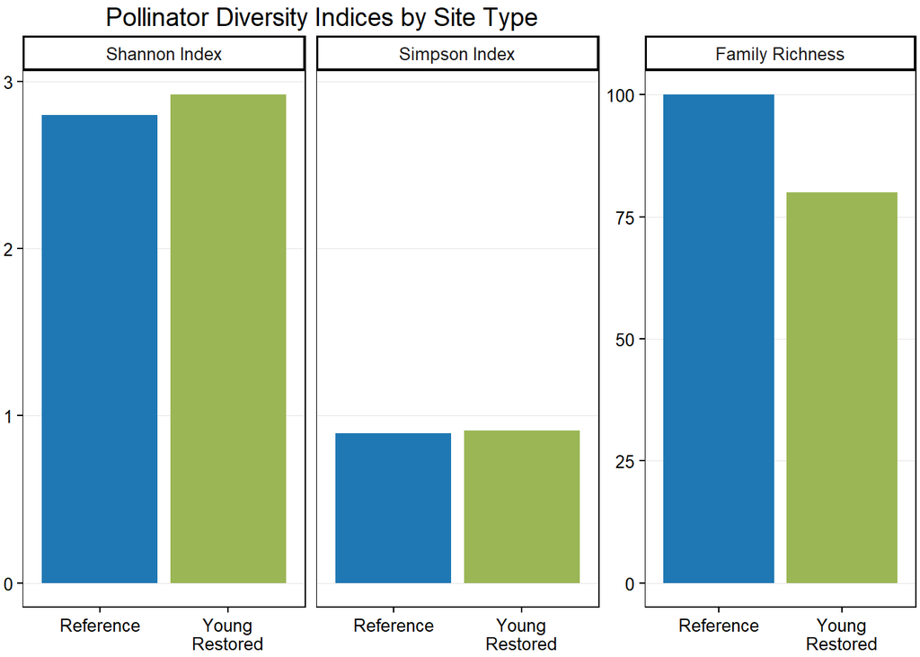

```r
#calculate species richness, shannon and simpson index for flower camera data with vegan package
# Calculate Hill numbers (species richness, Shannon, and Simpson index)
hill_numbers <- flower_cam %>%
  group_by(Site_Type, Family) %>%
  summarise(Count = n(), .groups = "drop") %>%
  pivot_wider(names_from = Family, values_from = Count, values_fill = list(Count = 0)) %>%
  column_to_rownames(var = "Site_Type") %>%
  # Calculate Hill numbers
  mutate(Species_Richness = specnumber(.),
         Shannon_Index = diversity(., index = "shannon"),
         Simpson_Index = diversity(., index = "simpson"))%>%
  #remove all columns that are not "Species_Richness", "Shannon_Index" or "Simpson_Index"
  dplyr::select(Species_Richness, Shannon_Index, Simpson_Index) %>%
  #add column "Site_Type" with value "Young Restored" or "Reference"
  mutate(Site_Type = rownames(.))

# Hill numbers long format
hill_numbers_long <- hill_numbers %>%
  pivot_longer(cols = c(Species_Richness, Shannon_Index, Simpson_Index),
               names_to = "Index",
               values_to = "Value")

#index labels
facet_labels <- c("Species_Richness" = "Family Richness",
                  "Shannon_Index" = "Shannon Index",
                  "Simpson_Index" = "Simpson Index")

# Barplot of Shannon and Simpson indices (filtered out species richness)
shan_simp <- hill_numbers_long %>%
  filter(Index != "Species_Richness") %>%
  ggplot(aes(x = Site_Type, y = Value, fill = Site_Type)) +
  geom_bar(stat = "identity", position = "dodge") +
  #  theme_minimal() +
  facet_wrap(~ Index, labeller = labeller(Index = facet_labels)) +  # Apply custom facet labels
  scale_fill_manual(values = custom_colors) +   # Apply custom colors
  theme(
    legend.position = "none",
    axis.title.x = element_blank(),   # Remove x-axis title
    axis.title.y = element_blank(),   # Remove y-axis title
  ) +
  scale_x_discrete(labels = function(x) gsub("Young Restored", "Young\nRestored", x))  # Split label into two lines

# Barplot of Species Richness
rich <- hill_numbers_long %>%
  filter(Index == "Species_Richness") %>%
  ggplot(aes(x = Site_Type, y = Value, fill = Site_Type)) +
  geom_bar(stat = "identity", position = "dodge") +
  #  theme_minimal() +
  facet_wrap(~ Index, labeller = labeller(Index = facet_labels)) +  # Apply custom facet labels
  scale_fill_manual(values = custom_colors, name = "Site Type") +   # Apply custom colors
  theme(
    legend.position = "none",
    axis.title.x = element_blank(),   # Remove x-axis title
    axis.title.y = element_blank(),   # Remove y-axis title
    scale_y_continuous(position = "left"),# Put y-axis on the left side instead of right
    legend.title = element_text(size = 10),  # Adjust legend title font size
    legend.text = element_text(size = 8)    # Adjust legend text font size
  ) +
  scale_x_discrete(labels = function(x) gsub("Young Restored", "Young\nRestored", x))  # Split label into two lines

# Create a left-aligned title grob
left_title <- textGrob(
  "Pollinator Diversity Indices by Site Type",
  gp = gpar(fontsize = 14), # <- left-align horizontally
  x = unit(0.35, "npc") # Slight shift to the right
  #y = unit(0.95, "npc")   # Position title vertically
)


# Plot the 2 plots side by side, and add the title defined right above
combined_plot_flowcam <- grid.arrange(
  shan_simp,
  rich,
  ncol = 2,
  top = left_title,
  widths = c(1.33, 0.7)
)
```

```r
# Save the combined plot
#ggsave("combined_diversity_indices.png", plot = combined_plot, width = 12, height = 6, dpi = 300)
```

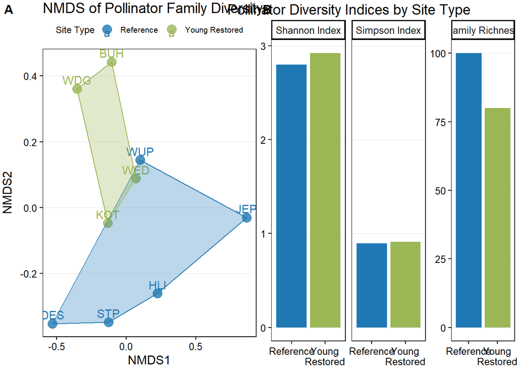

```r
#combine nmds_netting and hill numbers plots
library(cowplot)
(combi3<- cowplot::plot_grid(
  nmds_flowercam+theme(legend.position = "top"),
  combined_plot_flowcam,
  ncol =2,
  labels = c("A", "B"),
  label_size = 12
  #proportional height
  #rel_widths = c(0.8, 1.1)
))
```

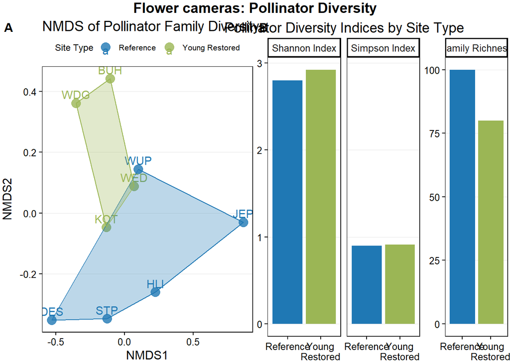

```r
(combi_final <- ggdraw() +
  draw_label("Flower cameras: Pollinator Diversity", fontface = 'bold', x = 0.5, y = 0.98, hjust = 0.5, size = 14) +
  draw_plot(combi3, y = 0, height = 0.95))
```

```r
#save the combined plot

ggsave("C:/Users/Almas/Desktop/UNI_LEIPSI/Thesis/Thesis_Rproject/figures/combi_flowercam.png",
       plot = combi_final,
       width = 12, height = 6, dpi =600)
```

## 7.4. Flower camera - NMDS flower species

```r
# Step 1: Create the community matrix
community_matrix_flo <- flower_cam %>%
  group_by(flower_sp, Family) %>%
  summarise(Count = n(), .groups = "drop") %>%
  pivot_wider(names_from = Family, values_from = Count, values_fill = list(Count = 0)) %>%
  column_to_rownames(var = "flower_sp") # Convert 'site' column to row names

# Step 2: Perform NMDS using Bray-Curtis distance
set.seed(123)
nmds_result_flo <- metaMDS(community_matrix_flo, distance = "bray", k = 2, trymax = 100)
```

```
## Square root transformation
## Wisconsin double standardization
## *** Best solution repeated 2 times
```

```r
# View results
print(nmds_result_flo)
```

```
##
## Call:
## metaMDS(comm = community_matrix_flo, distance = "bray", k = 2,      trymax = 100)
##
## global Multidimensional Scaling using monoMDS
##
## Data:     wisconsin(sqrt(community_matrix_flo))
## Distance: bray
##
## Dimensions: 2
## Stress:     0.09147095
## Stress type 1, weak ties
## Best solution was repeated 2 times in 20 tries
## The best solution was from try 19 (random start)
## Scaling: centring, PC rotation, halfchange scaling
## Species: expanded scores based on 'wisconsin(sqrt(community_matrix_flo))'
```

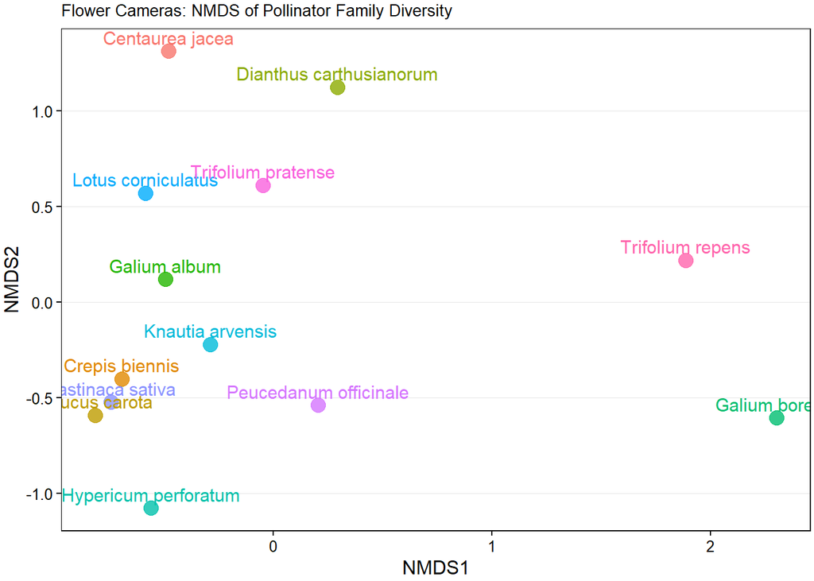

```r
# Step 3: Extract site scores for plotting
site_scores_flo <- as.data.frame(scores(nmds_result_flo, display = "sites"))
site_scores_flo$flower <- rownames(site_scores_flo)

# Step 5: Plot with customized colors
ggplot(site_scores_flo, aes(x = NMDS1, y = NMDS2, color = flower, label = flower)) +
  geom_point(size = 4, alpha = 0.8, shape=19) + # Adjust alpha for transparency if needed
  geom_text(vjust = -0.5, size = 4) +
  scale_fill_manual(values = custom_colors) + # Apply fill colors to polygons
  #  theme_minimal() +
  labs(title = "Flower Cameras: NMDS of Pollinator Family Diversity",
       x = "NMDS1",
       y = "NMDS2",
       color = "Flower Species")+ # Update legend title
  theme(legend.position = "none")
```

# 8. Comparison of the three methods

## 8.1. NMDS - all methods

```r
#create a dataframe called flower with these columns Site Date Family Count Method
flower <- flower_cam %>%
  dplyr::select(site, date, Family) %>%
  rename(Site = site, Date = date)%>%
  group_by(Site, Family) %>%
  summarise(Count = n(), .groups = "drop")%>%
  mutate(Method = "Flower camera")


# Combine all three methods into one dataframe
all_meth <- trad_meth %>%
  #remove date, transect columns
  dplyr::select(-Date, -Transect) %>%
  #combine with flower data
  rbind(flower)
```

```r
# Create a community matrix with Site and Transect combined
community_matrix_all_meth <- all_meth %>%
  group_by(Site, Family) %>%
  summarise(Count = sum(Count), .groups = "drop") %>%
  pivot_wider(names_from = Family, values_from = Count, values_fill = 0) %>%
  column_to_rownames(var = "Site") # Convert 'Site' column to row names

# Perform NMDS using Bray-Curtis distance
set.seed(123)
nmds_result_all_meth <- metaMDS(community_matrix_all_meth, distance = "bray", k = 2, trymax = 100)
```

```
## Square root transformation
## Wisconsin double standardization
## *** Best solution repeated 3 times
```

```r
# View results
print(nmds_result_all_meth)
```

```
##
## Call:
## metaMDS(comm = community_matrix_all_meth, distance = "bray",      k = 2, trymax = 100)
##
## global Multidimensional Scaling using monoMDS
##
## Data:     wisconsin(sqrt(community_matrix_all_meth))
## Distance: bray
##
## Dimensions: 2
## Stress:     0.1135385
## Stress type 1, weak ties
## Best solution was repeated 3 times in 20 tries
## The best solution was from try 6 (random start)
## Scaling: centring, PC rotation, halfchange scaling
## Species: expanded scores based on 'wisconsin(sqrt(community_matrix_all_meth))'
```

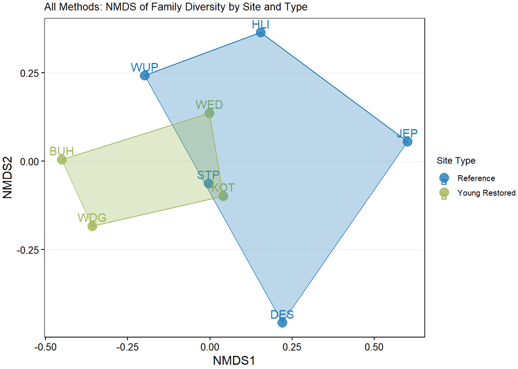

```r
# Extract site scores for plotting
site_scores_all_meth <- as.data.frame(scores(nmds_result_all_meth, display = "sites"))
site_scores_all_meth$Site <- rownames(site_scores_all_meth)

# Create a vector indicating site type (restored vs. reference)
site_scores_all_meth <- site_scores_all_meth %>%
  #if the site names begins with "WED_", "KOT_", "WDG_", "BUH_" then it is a "Young Restored" site, otherwise it is a "Reference" site
  mutate(Site_Type = ifelse(str_detect(Site, "WED|KOT|WDG|BUH"), "Young Restored", "Reference"))

# Custom color palette
#custom_colors <- c("Young Restored" = "steelblue", "Reference" = "darkorange")
custom_colors <- c("Young Restored" = "#9BB655FF", "Reference" = "#1F78B4")

# Plot with customized colors
ggplot(site_scores_all_meth, aes(x = NMDS1, y = NMDS2, color = Site_Type, label = Site)) +
  geom_point(size = 4, alpha = 0.8) + # Adjust alpha for transparency if needed
  geom_text(vjust = -0.5, size = 4) +
  scale_color_manual(values = custom_colors) + # Apply custom colors
  geom_polygon(data = site_scores_all_meth %>%
                 group_by(Site_Type) %>%
                 slice(chull(NMDS1, NMDS2)),
               aes(group = Site_Type, fill = Site_Type),
               alpha = 0.3, show.legend = FALSE) + # Add convex hull
  scale_fill_manual(values = custom_colors) + # Apply fill colors to polygons
  #  theme_minimal() +
  labs(title = "All Methods: NMDS of Family Diversity by Site and Type",
       x = "NMDS1",
       y = "NMDS2",
       color = "Site Type") # Update legend title
```

## 8.2. All methods - PERMANOVA & ANOSIM

```r
#all methods community matrix
community_matrix_all_meth <- all_meth %>%
  group_by(Site, Family) %>%
  summarise(Count = n(), .groups = "drop") %>%
  pivot_wider(names_from = Family, values_from = Count, values_fill = list(Count = 0)) %>%
  column_to_rownames(var = "Site") # Convert 'site' column to row names

#Compute the Bray-Curtis distance
bc_distance_all_meth <- vegdist(community_matrix_all_meth, method = "bray")
# Create a metadata table
site_metadata_all_meth <- data.frame(
  Site = rownames(community_matrix_all_meth),
  Site_Type = ifelse(rownames(community_matrix_all_meth) %in% c("WED", "KOT", "WDG", "BUH"),
                     "Young restored", "Reference")
)
#Make sure rownames match the order in bc_distance:
site_metadata_all_meth <- site_metadata_all_meth[match(rownames(community_matrix_all_meth), site_metadata_all_meth$Site), ]
#Run PERMANOVA using adonis2()
permanova_all_meth <- adonis2(bc_distance_all_meth ~ Site_Type, data = site_metadata_all_meth, permutations = 999)
print(permanova_all_meth)
```

```
## Permutation test for adonis under reduced model
## Terms added sequentially (first to last)
## Permutation: free
## Number of permutations: 999
##
## adonis2(formula = bc_distance_all_meth ~ Site_Type, data = site_metadata_all_meth, permutations = 999)
##           Df SumOfSqs      R2      F Pr(>F)
## Site_Type  1  0.11924 0.17606 1.4957  0.092 .
## Residual   7  0.55803 0.82394
## Total      8  0.67727 1.00000
## ---
## Signif. codes:  0 '***' 0.001 '**' 0.01 '*' 0.05 '.' 0.1 ' ' 1
```

```r
#ANOSIM for additional insight
anosim_result_all_meth <- anosim(bc_distance_all_meth, grouping = site_metadata_all_meth$Site_Type, permutations = 999)
summary(anosim_result_all_meth)
```

```
##
## Call:
## anosim(x = bc_distance_all_meth, grouping = site_metadata_all_meth$Site_Type,      permutations = 999)
## Dissimilarity: bray
##
## ANOSIM statistic R: 0.275
##       Significance: 0.066
##
## Permutation: free
## Number of permutations: 999
##
## Upper quantiles of permutations (null model):
##   90%   95% 97.5%   99%
## 0.237 0.294 0.362 0.406
##
## Dissimilarity ranks between and within classes:
##                0%   25%  50%   75% 100%  N
## Between         5 14.50 21.5 26.25   34 20
## Reference       2 11.00 17.5 30.75   36 10
## Young restored  1  3.75  6.5  8.50   29  6
```

## 8.3. All methods - NMDS split

```r
# Create a community matrix with Site and Method combined
community_matrix_all_meth_split <- all_meth %>%
  mutate(Site_Meth = paste(Site, Method, sep = "_")) %>% # Combine Site and Method
  group_by(Site_Meth, Family) %>%
  summarise(Count = sum(Count), .groups = "drop") %>%
  pivot_wider(names_from = Family, values_from = Count, values_fill = 0) %>%
  column_to_rownames(var = "Site_Meth") # Use combined Site_Transect as row names

# Perform NMDS using Bray-Curtis distance
set.seed(123)
nmds_result_all_meth_split <- metaMDS(community_matrix_all_meth_split, distance = "bray", k = 2, trymax = 100)
```

```
## Square root transformation
## Wisconsin double standardization
## *** Best solution was not repeated -- monoMDS stopping criteria:
##     41: no. of iterations >= maxit
##     59: stress ratio > sratmax
```

```r
# View results
print(nmds_result_all_meth_split)
```

```
##
## Call:
## metaMDS(comm = community_matrix_all_meth_split, distance = "bray",      k = 2, trymax = 100)
##
## global Multidimensional Scaling using monoMDS
##
## Data:     wisconsin(sqrt(community_matrix_all_meth_split))
## Distance: bray
##
## Dimensions: 2
## Stress:     0.112744
## Stress type 1, weak ties
## Best solution was not repeated after 100 tries
## The best solution was from try 27 (random start)
## Scaling: centring, PC rotation, halfchange scaling
## Species: expanded scores based on 'wisconsin(sqrt(community_matrix_all_meth_split))'
```

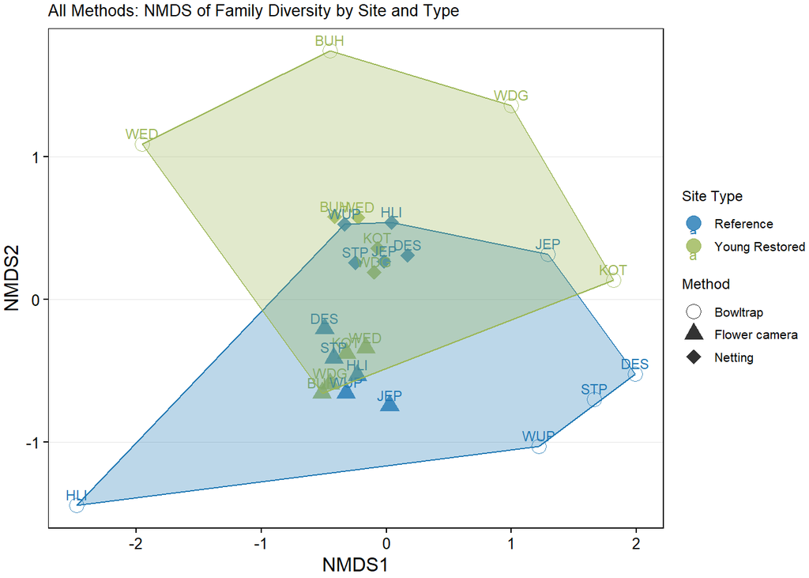

```r
# Extract site scores for plotting
site_scores_all_meth_split <- as.data.frame(scores(nmds_result_all_meth_split, display = "sites"))
site_scores_all_meth_split$Site <- rownames(site_scores_all_meth_split)

# Create a vector indicating site type (restored vs. reference)
site_scores_all_meth_split <- site_scores_all_meth_split %>%
  #if the site names begins with "WED_", "KOT_", "WDG_", "BUH_" then it is a "Young Restored" site, otherwise it is a "Reference" site
  mutate(Site_Type = ifelse(str_detect(Site, "WED|KOT|WDG|BUH"), "Young Restored", "Reference")) %>%
  #if the site names ends with "_Bowltrap" then it is a "Bowltrap" site, if it ends with "_Netting" then it is a "Netting" site, otherwise it is a "Flower camera" site
  mutate(Method = ifelse(str_detect(Site, "_Bowltrap"), "Bowltrap",
                         ifelse(str_detect(Site, "_Netting"), "Netting", "Flower camera"))) %>%
  #only keep first 3 letters of the site name
  mutate(Site = str_sub(Site, 1, 3))

# Custom color palette
#custom_colors <- c("Young Restored" = "steelblue", "Reference" = "darkorange")
custom_colors <- c("Young Restored" = "#9BB655FF", "Reference" = "#1F78B4")
custom_shapes <- c("Bowltrap" = 1, "Netting" = 18, "Flower camera" = 17) # 16 = solid circle, 17 = triangle
# Plot with customized colors and shapes for Method
ggplot(site_scores_all_meth_split, aes(x = NMDS1, y = NMDS2, color = Site_Type, label = Site, shape = Method)) +
  geom_point(size = 4, alpha = 0.8) + # Adjust alpha for transparency if needed
  geom_text(vjust = -0.5, size = 3) +  # Adjust text position
  scale_color_manual(values = custom_colors) + # Apply custom colors
  scale_shape_manual(values = custom_shapes) + # Apply custom shapes
  geom_polygon(data = site_scores_all_meth_split %>%
                 group_by(Site_Type) %>%
                 slice(chull(NMDS1, NMDS2)),
               aes(group = Site_Type, fill = Site_Type),
               alpha = 0.3, show.legend = FALSE) + # Add convex hull
  scale_fill_manual(values = custom_colors) + # Apply fill colors to polygons
  #  theme_minimal() +
  labs(title = "All Methods: NMDS of Family Diversity by Site and Type",
       x = "NMDS1",
       y = "NMDS2",
       color = "Site Type",
       shape = "Method") # Update legend title
```

# 9. NETTING AND FLOWER CAMERA

## 9.1. Netting and flower camera - NMDS split

```r
# Create a community matrix with Site and Transect combined
community_matrix_net_flo <- all_meth %>%
  filter(Method %in% c("Netting", "Flower camera")) %>% # Filter for Netting and Flower camera methods only
  mutate(Site_Meth = paste(Site, Method, sep = "_")) %>% # Combine Site and Method
  group_by(Site_Meth, Family) %>%
  summarise(Count = sum(Count), .groups = "drop") %>%
  pivot_wider(names_from = Family, values_from = Count, values_fill = 0) %>%
  column_to_rownames(var = "Site_Meth") # Use combined Site_Transect as row names


# Perform NMDS using Bray-Curtis distance
set.seed(123)
nmds_result_net_flo <- metaMDS(community_matrix_net_flo, distance = "bray", k = 2, trymax = 100)
```

```
## Square root transformation
## Wisconsin double standardization
## *** Best solution repeated 1 times
```

```r
# View results
print(nmds_result_net_flo)
```

```
##
## Call:
## metaMDS(comm = community_matrix_net_flo, distance = "bray", k = 2,      trymax = 100)
##
## global Multidimensional Scaling using monoMDS
##
## Data:     wisconsin(sqrt(community_matrix_net_flo))
## Distance: bray
##
## Dimensions: 2
## Stress:     0.1126824
## Stress type 1, weak ties
## Best solution was repeated 1 time in 20 tries
## The best solution was from try 14 (random start)
## Scaling: centring, PC rotation, halfchange scaling
## Species: expanded scores based on 'wisconsin(sqrt(community_matrix_net_flo))'
```

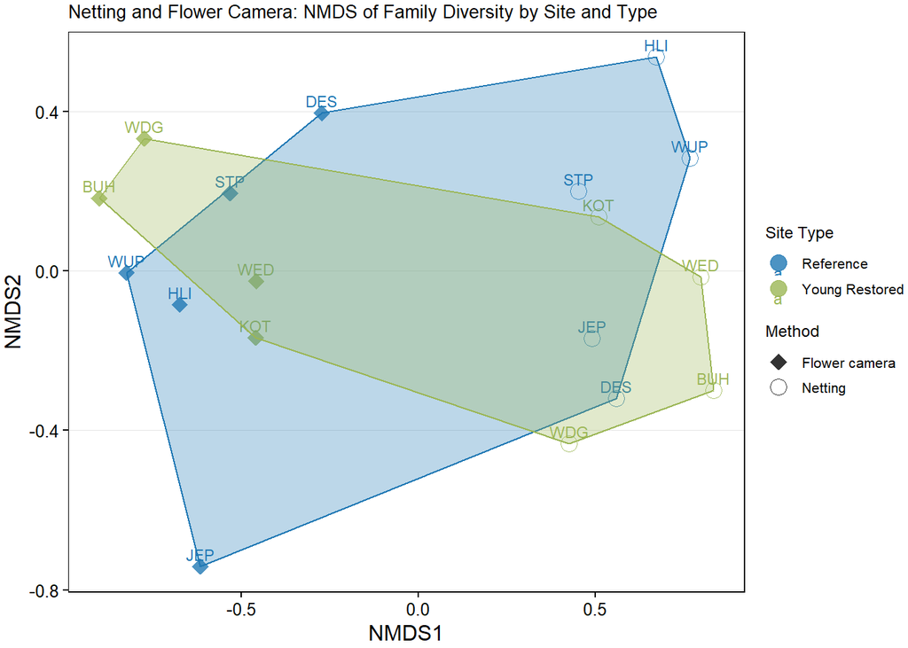

```r
# Extract site scores for plotting
site_scores_net_flo <- as.data.frame(scores(nmds_result_net_flo, display = "sites"))
site_scores_net_flo$Site <- rownames(site_scores_net_flo)
# Create a vector indicating site type (restored vs. reference)
site_scores_net_flo <- site_scores_net_flo %>%
  #if the site names begins with "WED_", "KOT_", "WDG_", "BUH_" then it is a "Young Restored" site, otherwise it is a "Reference" site
  mutate(Site_Type = ifelse(str_detect(Site, "WED|KOT|WDG|BUH"), "Young Restored", "Reference")) %>%
  #if the site names ends with "_Netting" then it is a "Netting" site, otherwise it is a "Flower camera" site
  mutate(Method = ifelse(str_detect(Site, "_Netting"), "Netting", "Flower camera")) %>%
  #only keep first 3 letters of the site name
  mutate(Site = str_sub(Site, 1, 3))

# Custom color palette
#custom_colors <- c("Young Restored" = "steelblue", "Reference" = "darkorange")
custom_colors <- c("Young Restored" = "#9BB655FF", "Reference" = "#1F78B4")
custom_shapes <- c("Netting" = 1, "Flower camera" = 18) # 16 = solid circle, 17 = triangle
# Plot with customized colors and shapes for Method
ggplot(site_scores_net_flo, aes(x = NMDS1, y = NMDS2, color = Site_Type, label = Site, shape = Method)) +
  geom_point(size = 4, alpha = 0.8) + # Adjust alpha for transparency if needed
  geom_text(vjust = -0.5, size = 3) +  # Adjust text position
  scale_color_manual(values = custom_colors) + # Apply custom colors
  scale_shape_manual(values = custom_shapes) + # Apply custom shapes
  geom_polygon(data = site_scores_net_flo %>%                  group_by(Site_Type) %>%                 slice(chull(NMDS1, NMDS2)),               aes(group = Site_Type, fill = Site_Type),               alpha = 0.3, show.legend = FALSE) + # Add convex hull
  scale_fill_manual(values = custom_colors) + # Apply fill colors to polygons
  #  theme_minimal() +
  labs(title = "Netting and Flower Camera: NMDS of Family Diversity by Site and Type",
       x = "NMDS1",
       y = "NMDS2",
       color = "Site Type",
       shape = "Method") # Update legend title
```

## 9.2. Netting and flower camera - PERMANOVA & ANOSIM

```r
#netting and flower camera community matrix
community_matrix_net_flo <- all_meth %>%
  filter(Method %in% c("Netting", "Flower camera")) %>% # Filter for Netting and Flower camera methods only
  group_by(Site, Family) %>%
  summarise(Count = n(), .groups = "drop") %>%
  pivot_wider(names_from = Family, values_from = Count, values_fill = list(Count = 0)) %>%
  column_to_rownames(var = "Site") # Convert 'site' column to row names
#Compute the Bray-Curtis distance
bc_distance_net_flo <- vegdist(community_matrix_net_flo, method = "bray")
# Create a metadata table
site_metadata_net_flo <- data.frame(
  Site = rownames(community_matrix_net_flo),
  Site_Type = ifelse(rownames(community_matrix_net_flo) %in% c("WED", "KOT", "WDG", "BUH"),
                     "Young restored", "Reference")
)
#Make sure rownames match the order in bc_distance:
site_metadata_net_flo <- site_metadata_net_flo[match(rownames(community_matrix_net_flo), site_metadata_net_flo$Site), ]
#Run PERMANOVA using adonis2()
permanova_net_flo <- adonis2(bc_distance_net_flo ~ Site_Type, data = site_metadata_net_flo, permutations = 999)
print(permanova_net_flo)
```

```
## Permutation test for adonis under reduced model
## Terms added sequentially (first to last)
## Permutation: free
## Number of permutations: 999
##
## adonis2(formula = bc_distance_net_flo ~ Site_Type, data = site_metadata_net_flo, permutations = 999)
##           Df SumOfSqs      R2      F Pr(>F)
## Site_Type  1  0.10827 0.17349 1.4694  0.133
## Residual   7  0.51581 0.82651
## Total      8  0.62408 1.00000
```

```r
#ANOSIM for additional insight
anosim_result_net_flo <- anosim(bc_distance_net_flo, grouping = site_metadata_net_flo$Site_Type, permutations = 999)
summary(anosim_result_net_flo)
```

```
##
## Call:
## anosim(x = bc_distance_net_flo, grouping = site_metadata_net_flo$Site_Type,      permutations = 999)
## Dissimilarity: bray
##
## ANOSIM statistic R: 0.2625
##       Significance: 0.106
##
## Permutation: free
## Number of permutations: 999
##
## Upper quantiles of permutations (null model):
##   90%   95% 97.5%   99%
## 0.263 0.302 0.394 0.413
##
## Dissimilarity ranks between and within classes:
##                0%   25%  50%   75% 100%  N
## Between         7 15.25 20.5 26.75   34 20
## Reference       4 12.50 21.0 30.25   36 10
## Young restored  1  2.25  4.0  8.75   25  6
```

## 9.3. Netting vs flower camera

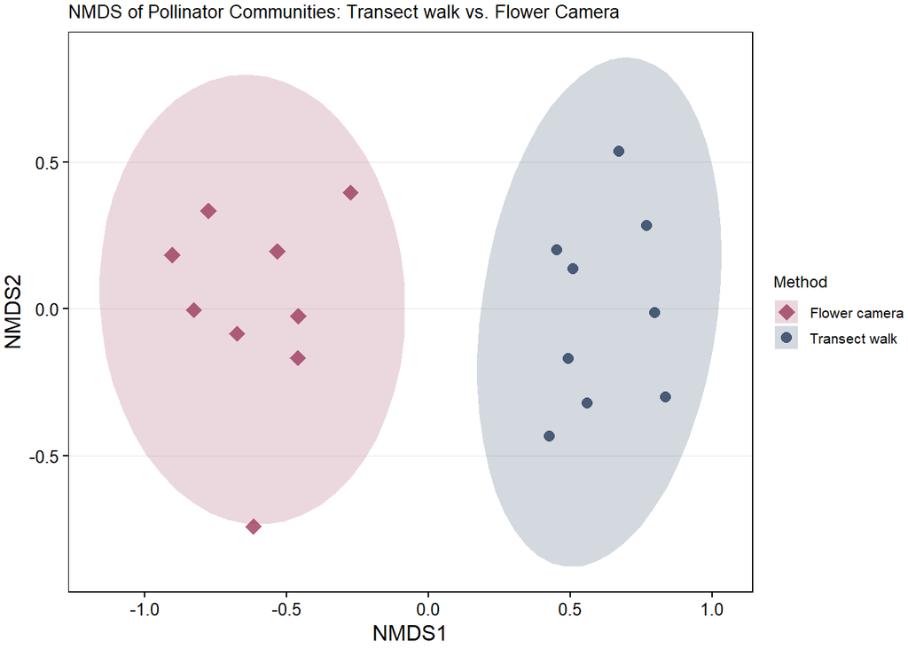

```r
library(vegan)
library(ggplot2)
library(dplyr)

# First, compute NMDS again (or reuse your existing nmds_result_net_flo)
# Assuming you already have:
# nmds_result_net_flo and site_scores_net_flo

# Compute group centroids (average NMDS position per Method)
centroids <- site_scores_net_flo %>%
  group_by(Method) %>%
  summarise(NMDS1 = mean(NMDS1), NMDS2 = mean(NMDS2))


# Rename "Netting" to "Transect walk" in Method column
site_scores_net_flo <- site_scores_net_flo %>%
  mutate(Method = recode(Method, "Netting" = "Transect walk"))

# Plot
ggplot(site_scores_net_flo, aes(x = NMDS1, y = NMDS2, color = Method, shape = Method)) +
  geom_point(size = 4, alpha = 0.8) +
  stat_ellipse(aes(fill = Method), geom = "polygon", alpha = 0.2, color = NA) +
  scale_color_manual(values = c("Transect walk" = "#263D5DFF", "Flower camera" = "#9D3A5EFF")) +
  scale_fill_manual(values = c("Transect walk" = "#263D5DFF", "Flower camera" = "#9D3A5EFF")) +
  scale_shape_manual(values = c("Transect walk" = 20, "Flower camera" = 18)) +
  labs(
    title = "NMDS of Pollinator Communities: Transect walk vs. Flower Camera",
    x = "NMDS1", y = "NMDS2",
    color = "Method", shape = "Method", fill = "Method"
  )
```

```r
# Ensure "Netting" is renamed to "Transect walk"
site_scores_net_flo <- site_scores_net_flo %>%
  mutate(Method = recode(Method, "Netting" = "Transect walk"))%>%
  #add Site_type
  mutate(Site_Type = ifelse(Site %in% c("WED", "KOT", "WDG", "BUH"), "Young Restored", "Reference"))

library(ggrepel)
```

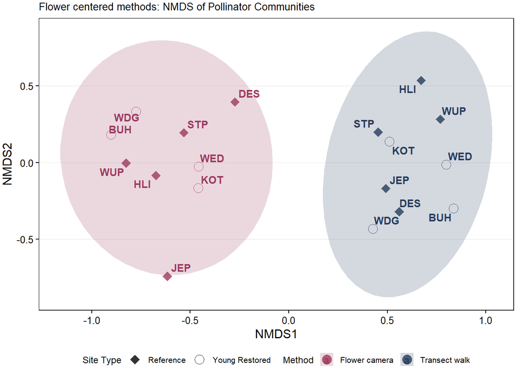

```r
# Plot
(plot1 <-ggplot(site_scores_net_flo, aes(x = NMDS1, y = NMDS2)) +
  # Points: color by Method, shape by Site Type
  geom_point(aes(color = Method, shape = Site_Type), size = 4, alpha = 0.8) +
  # Ellipses by Method
  stat_ellipse(aes(fill = Method), geom = "polygon", alpha = 0.2, color = NA) +
  # Site labels at the same spot as dots
  geom_text_repel(aes(label = Site, color = Method), size = 3.5, fontface = "bold", max.overlaps = 20) +
  # Manual colors and shapes
  scale_color_manual(values = c("Transect walk" = "#263D5DFF", "Flower camera" = "#9D3A5EFF")) +
  scale_fill_manual(values = c("Transect walk" = "#263D5DFF", "Flower camera" = "#9D3A5EFF")) +
  scale_shape_manual(values = c("Young Restored" = 1, "Reference" = 18)) +  # circle for restored, lozange for reference
  labs(
    title = "Flower centered methods: NMDS of Pollinator Communities",
    x = "NMDS1", y = "NMDS2",
    color = "Method", shape = "Site Type", fill = "Method"
  )+
  # legend position
  theme(legend.position = "bottom"))
```

```r
# Save the plot
ggsave("C:/Users/Almas/Desktop/UNI_LEIPSI/Thesis/Thesis_Rproject/figures/nmds_netting_flower.png",
       plot = plot1,
       width = 8, height = 6, dpi =600)
```

```r
# Assuming you have your community matrix (same one used for NMDS)
# and that 'Method' is in your metadata (site_scores_net_flo)

# Create a community matrix with Site and Transect combined
community_matrix_net_flo <- all_meth %>%
  filter(Method %in% c("Netting", "Flower camera")) %>% # Filter for Netting and Flower camera methods only
  mutate(Site_Meth = paste(Site, Method, sep = "_")) %>% # Combine Site and Method
  group_by(Site_Meth, Family) %>%
  summarise(Count = sum(Count), .groups = "drop") %>%
  pivot_wider(names_from = Family, values_from = Count, values_fill = 0) %>%
  column_to_rownames(var = "Site_Meth") # Use combined Site_Transect as row names


# Perform NMDS using Bray-Curtis distance
set.seed(123)
nmds_result_net_flo <- metaMDS(community_matrix_net_flo, distance = "bray", k = 2, trymax = 100)
```

```
## Square root transformation
## Wisconsin double standardization
## *** Best solution repeated 1 times
```

```r
# Compute Bray-Curtis distance
bc_distance <- vegdist(community_matrix_net_flo, method = "bray")

# View results
print(nmds_result_net_flo)
```

```
##
## Call:
## metaMDS(comm = community_matrix_net_flo, distance = "bray", k = 2,      trymax = 100)
##
## global Multidimensional Scaling using monoMDS
##
## Data:     wisconsin(sqrt(community_matrix_net_flo))
## Distance: bray
##
## Dimensions: 2
## Stress:     0.1126824
## Stress type 1, weak ties
## Best solution was repeated 1 time in 20 tries
## The best solution was from try 14 (random start)
## Scaling: centring, PC rotation, halfchange scaling
## Species: expanded scores based on 'wisconsin(sqrt(community_matrix_net_flo))'
```

```r
# Extract site scores for plotting
site_scores_net_flo <- as.data.frame(scores(nmds_result_net_flo, display = "sites"))
site_scores_net_flo$Site <- rownames(site_scores_net_flo)
# Create a vector indicating site type (restored vs. reference)
site_scores_net_flo <- site_scores_net_flo %>%
  #if the site names begins with "WED_", "KOT_", "WDG_", "BUH_" then it is a "Young Restored" site, otherwise it is a "Reference" site
  mutate(Site_Type = ifelse(str_detect(Site, "WED|KOT|WDG|BUH"), "Young Restored", "Reference")) %>%
  #if the site names ends with "_Netting" then it is a "Netting" site, otherwise it is a "Flower camera" site
  mutate(Method = ifelse(str_detect(Site, "_Netting"), "Netting", "Flower camera")) %>%
  #only keep first 3 letters of the site name
  mutate(Site = str_sub(Site, 1, 3))

# Run PERMANOVA testing difference between Methods
permanova_method <- adonis2(bc_distance ~ Method,
                            data = site_scores_net_flo,
                            permutations = 999)

# Run ANOSIM testing difference between Methods
anosim_result_method <- anosim(bc_distance, grouping = site_scores_net_flo$Method, permutations = 999)

#view results
print(permanova_method)
```

```
## Permutation test for adonis under reduced model
## Terms added sequentially (first to last)
## Permutation: free
## Number of permutations: 999
##
## adonis2(formula = bc_distance ~ Method, data = site_scores_net_flo, permutations = 999)
##          Df SumOfSqs      R2      F Pr(>F)
## Method    1   1.0148 0.22028 4.5203  0.002 **
## Residual 16   3.5920 0.77972
## Total    17   4.6068 1.00000
## ---
## Signif. codes:  0 '***' 0.001 '**' 0.01 '*' 0.05 '.' 0.1 ' ' 1
```

```r
summary(anosim_result_method)
```

```
##
## Call:
## anosim(x = bc_distance, grouping = site_scores_net_flo$Method,      permutations = 999)
## Dissimilarity: bray
##
## ANOSIM statistic R: 0.5127
##       Significance: 0.003
##
## Permutation: free
## Number of permutations: 999
##
## Upper quantiles of permutations (null model):
##   90%   95% 97.5%   99%
## 0.110 0.161 0.210 0.261
##
## Dissimilarity ranks between and within classes:
##               0%   25% 50%    75% 100%  N
## Between        6 70.00  99 127.00  153 81
## Flower camera  1 28.25  53 108.25  152 36
## Netting        2 17.75  39  65.00  143 36
```

## 9.3. Netting vs flower camera VENN DIAGRAM

```r
# Dark colors per site
dark_colors <- c(
  "DES" = "#1F78B4",    "HLI" = "#1F78B4",    "JEP" = "#1F78B4",    "STP" = "#1F78B4",  "WUP" = "#1F78B4",
  "BUH" = "#9BB655FF",    "KOT" = "#9BB655FF",    "WDG" = "#9BB655FF",    "WED" = "#9BB655FF"
)

# Light colors per site
light_colors <- c(
  "DES" = "lightblue",    "HLI" = "lightblue",    "JEP" = "lightblue",    "STP" = "lightblue",  "WUP" = "lightblue",
  "BUH" = "#D3D5AEFF",    "KOT" = "#D3D5AEFF",  "WDG" = "#D3D5AEFF",    "WED" = "#D3D5AEFF"
)
```

```r
library(ggVennDiagram)
```

```r
library(patchwork)  # for arranging plots
# Step 1: Get list of families per Site x Method
family_lists <- all_meth %>%
  filter(Method %in% c("Netting", "Flower camera")) %>% # Filter for Netting and Flower camera methods only
  group_by(Site, Method) %>%
  summarise(Families = list(unique(Family)), .groups = 'drop')

# Step 2: Function to draw Venn per site
draw_site_venn <- function(site_name) {
  site_data <- family_lists %>% filter(Site == site_name)

  # Only proceed if there are at least 2 methods with data
  if (nrow(site_data) < 2 || any(sapply(site_data$Families, length) == 0)) return(NULL)

  fam_list <- setNames(site_data$Families, site_data$Method)

  ggVennDiagram(fam_list, label_alpha = 0) +
    # Use site-specific dark color
    scale_fill_gradient(low = light_colors[site_name], high = dark_colors[site_name]) +
    labs(title = site_name) +
    theme(
      plot.margin = margin(10, 20, 10, 20),
      plot.title = element_text(hjust = 0.5, size = 14, face = "bold"),
      plot.background = element_rect(fill = "white", color = NA)
    ) +
    coord_cartesian(clip = "off")
}

# Step 3: Draw Venns for each site
plots <- lapply(unique(all_meth$Site), draw_site_venn)
```

```
## replace the existing one.
```

[output not shown]

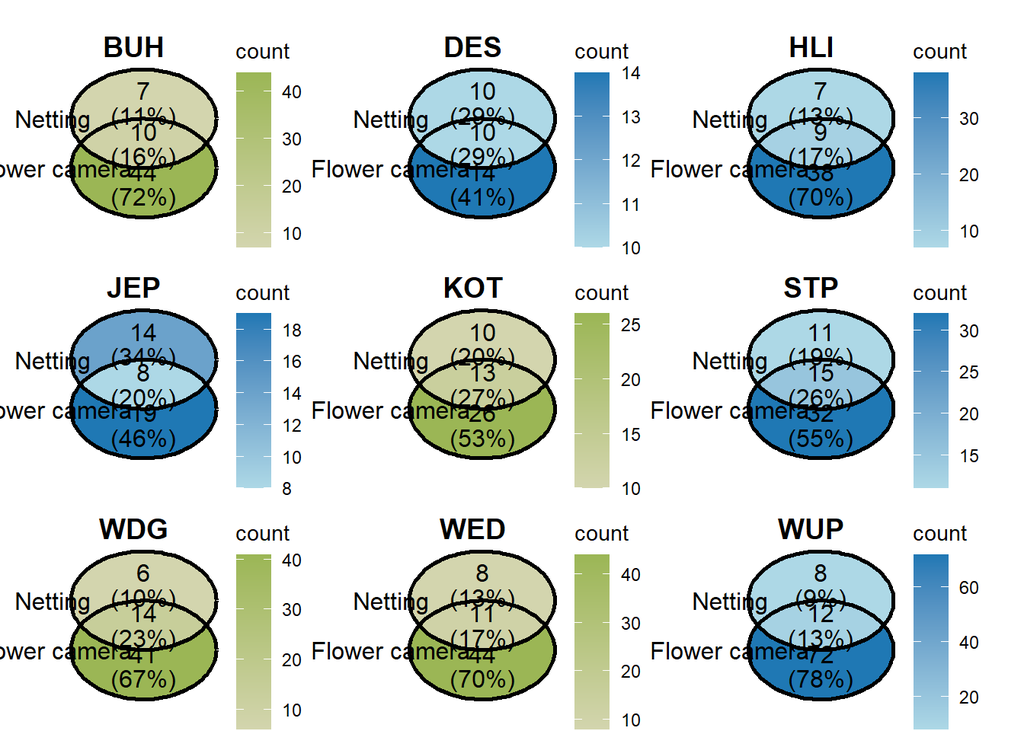

```r
# Remove NULLs (sites with missing data)
plots <- plots[!sapply(plots, is.null)]

# Step 4: Arrange in grid
wrap_plots(plots, ncol = 3)
```

```r
# Step 5: Save the plot
ggsave("C:/Users/Almas/Desktop/UNI_LEIPSI/Thesis/Thesis_Rproject/figures/net_flo_venn.png",
       width = 12, height = 12, dpi = 600)
```

```
## replace the existing one.
```

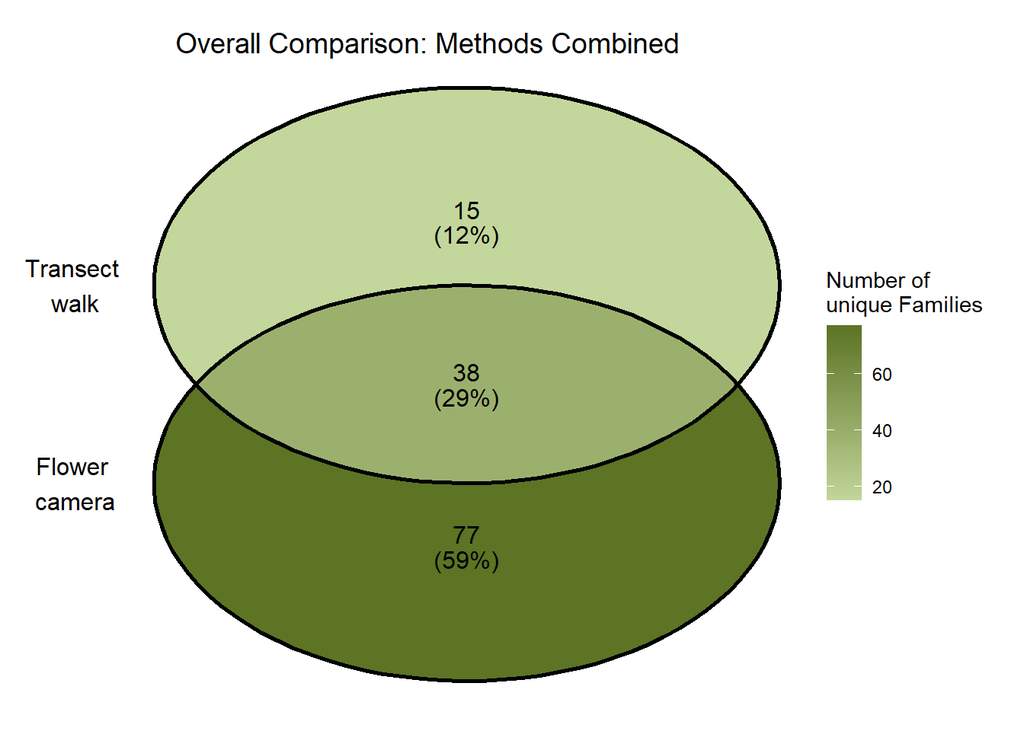

```r
library(tidyverse)
library(ggVennDiagram)

# Step 1: Define your method renaming
method_names <- c(
  "Bowltrap" = "Pan Traps",
  "Netting" = "Transect \nwalk",
  "Flower camera" = "Flower \ncamera"
)

# Step 2: Get unique families per Method (across all sites)
method_lists <- all_meth %>%
  filter(Method %in% c("Netting", "Flower camera")) %>% # Filter for Netting and Flower camera methods only
  group_by(Method) %>%
  summarise(Families = list(unique(Family)), .groups = 'drop')

# Step 3: Rename methods
method_lists <- method_lists %>%
  mutate(Method = method_names[Method])

# Step 4: Convert to named list
fam_list <- setNames(method_lists$Families, method_lists$Method)

# Step 5: Draw Venn diagram with renamed methods
(plot2 <-ggVennDiagram(fam_list, label_alpha = 0) +
  scale_fill_gradient(low = "#C3D69B", high = "#5C7424") +
  labs(title = "Overall Comparison: Methods Combined") +
  guides(fill = guide_colorbar(title = "Number of \nunique Families")) +
  theme(
    plot.margin = margin(10, 20, 10, 20),
    plot.title = element_text(hjust = 0.5, size = 14),
    plot.background = element_rect(fill = "white", color = NA)
  ) +
  coord_cartesian(clip = "off"))
```

```r
# Step : Save the plot
ggsave("C:/Users/Almas/Desktop/UNI_LEIPSI/Thesis/Thesis_Rproject/figures/venn_combined.png",
       width = 5, height = 5, dpi = 600)
```